# Day 3 - Metadata

Maggie L. Warren and Lucas A. Nell

2023-11-15

## What is metadata?

- It is data about your data
- Describes what your data is
- Important for making your data FAIR

[figure not shown]

Image created by SangyaPundir

## Metadata example

### Here’s an example of good metadata

https://carpentries-incubator.github.io/fair-bio-practice/05-intro-to-metadata/index.html#image-metadata

## Types of metadata

- Administrative metadata
  - assigned to data before it’s creation or collection
  - E.g. funder, project collaborators, principle investigator, etc.
- Descriptive or citation metadata
  - data that helps people find your data or resource
  - E.g. keywords, persistent identifier, abstract, authors, etc.
- Structural metadata
  - How the data was collected/created and how it’s structured
  - E.g. Sampling procedure, sample size, variables, units, collection method, etc.

## Identify different metadata types

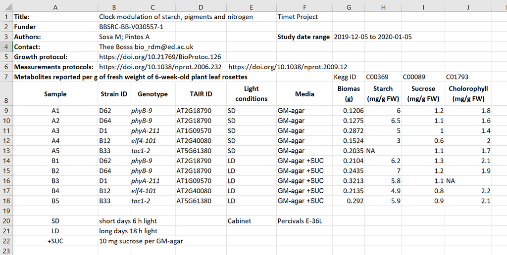

Image from https://carpentries-incubator.github.io/fair-bio-practice/05-intro-to-metadata/index.html#image-metadata

## Activity: Identify what metadata you need

### **What kinds of data do (will) you have for your project?**

- Dryad - https://datadryad.org/stash/requirements; https://datadryad.org/stash/best_practices
- Zenodo - https://about.zenodo.org/principles/
- GenBank - https://www.ncbi.nlm.nih.gov/genbank/submit_types/
- What types of metadata do you need?

## Common spreadsheet errors

### Multiple tables

- Using multiple tables

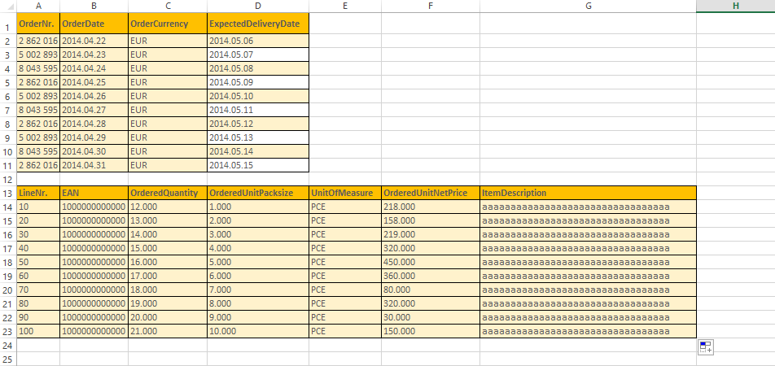

Image from https://stackoverflow.com/questions/23289882/how-to-add-multiple-tables-conversion-from-excel-xls-file-to-xml-c-sharp

### Multiple tabs

- Using multiple tabs
  - Sometimes these can be missed
  - Difficult to use in code

[figure not shown]

Image from https://blog.datawrapper.de/prepare-and-clean-up-data-for-data-visualization/

### Not filling in zeros

```
* Difference between a zero and a blank cell
```

### Using problematic null values

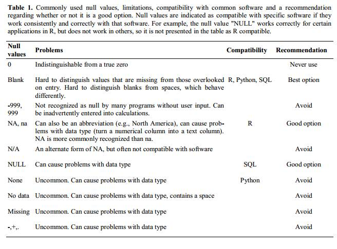

Image from White et al. 2013, *PeerJ Preprints*

### Using formatting to convey information: highlighting

- Highlighting cells

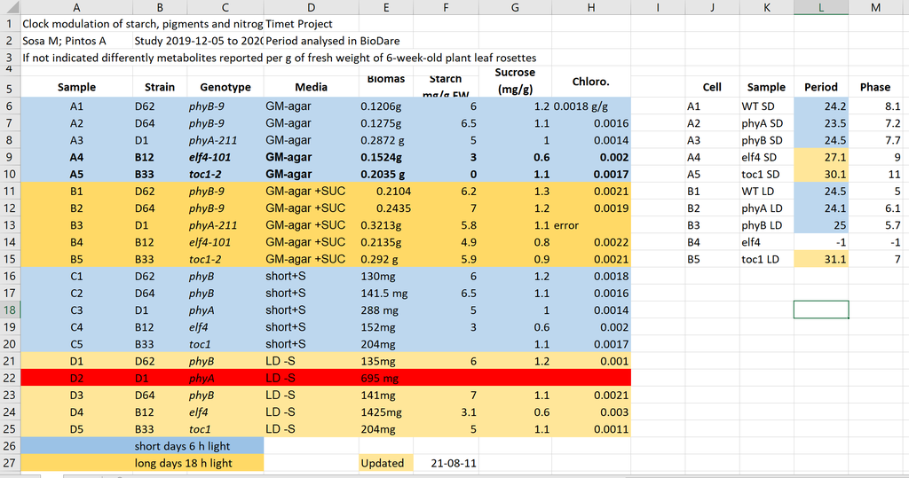

Image from https://carpentries-incubator.github.io/fair-bio-practice/07-data-in-excel/index.html

### Using formatting to convey information: merging cells

- Merging cells

[figure not shown]

### Other common errors

- Placing comments or units in cells
  - E.g. 0.123g
- Having more than one piece of information in a cell
  - “ID=g24074.t1;Parent=g24074;Alias=g24074.t1;gene=Dupd1;gene_id=Dupd1.g1;description=Similar to Dual specificity protein phosphatase [Sphaeramia orbicularis];Dbxref=InterPro:IPR000387,InterPro:IPR016130,InterPro:IPR020405,InterPro:IPR020422,InterPro:IPR029021,PANTHER:PTHR45682,PANTHER:PTHR45682:SF2,PRINTS:PR01908,PRINTS:PR01909,PFAM:PF00782,ProSitePatterns:PS00383,ProSiteProfiles:PS50054,ProSiteProfiles:PS50056,SMART:SM00195,SUPERFAMILY:SSF52799;Ontology_term=GO:0004725,GO:0016311,GO:0016791;”
- Inconsistent values
  - E.g. Using E. Coli, Escherichia coli, and Ecoli
- Using special characters, spaces, or numbers in column names

## Tidy data

### What makes data tidy?

```
1. Every column is a variable
2. Every row is an observation
3. Ever cell is a single value
```

## Real life example

Wrangling plate reader data

## Practice making tidy data

- In your group discuss what is wrong with the format of your data
- Create a repository for your metadata project
- Clone the repository to your local git
- Delegate jobs to group members:
  - write readme describing the data
  - reshape the data into a tidy form and change to csv
  - read the data into R making sure it is in the right form
- Each role will push changes to a new branch of the main branch
- As a group pull the changes merging the branches to the main branch

## Conclusion

- What kind of metadata do you need for your project?
- How will this metadata be organized in your directory?
- Create metadata for your project data for next class